GLevitin · Cap. 9

Diseño algorítmico

# Elegir ahora. *Ganar al final.*

Un algoritmo voraz construye la solución con decisiones factibles, localmente óptimas e irrevocables. La intuición es simple; demostrar que funciona es la parte profunda.

**3**reglas de cada elección

**4**algoritmos clásicos

**1**decisión por paso

Siguiente decisión

### ¿Qué opción tomar?

*A*Factible · coste 7**7**

*B*Factible · coste 3**3 ✓**

*C*No factible**—**

01 · Patrón

## La promesa voraz

La mejor decisión disponible se incorpora sin volver atrás. Eso es potente solo cuando la estructura del problema lo permite.

Factible

### Respeta restricciones

Una arista no puede crear ciclos en Kruskal; una moneda no puede exceder el saldo pendiente.

Localmente óptima

### Es la mejor ahora

Menor arista, menor distancia tentativa o dos frecuencias mínimas, según el problema.

Irrevocable

### No se deshace

La elección entra definitivamente en la solución parcial. Por eso la prueba de corrección importa.

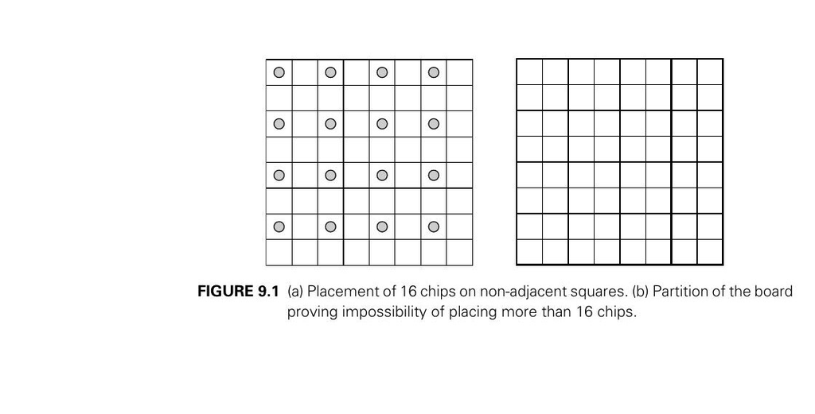

Figura 9.1: una construcción voraz y una cota que demuestra su optimalidad.

02 · ¿Siempre funciona?

## Cambio: voraz vs. óptimo

Tomar siempre la moneda más grande funciona para algunos sistemas monetarios, pero falla para otros.

### Banco de pruebas

DenominacionesMonto

03 · Árbol mínimo

## Prim: expandir una isla

Parte de un vértice y añade la arista más barata que conecta el árbol actual con un vértice externo.

### Simulador de Prim

Vértice inicial

**1/7**vértices

**0**peso acumulado

**0**aristas

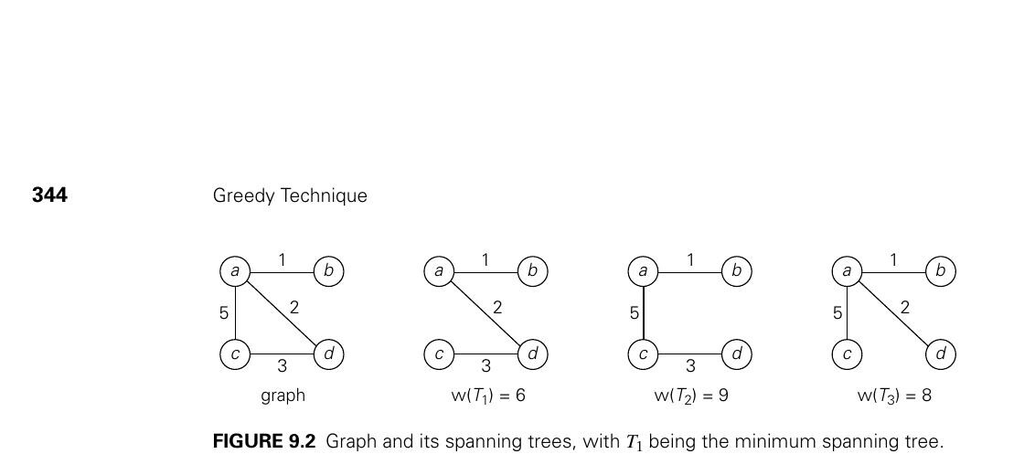

Figura 9.2: árboles de expansión con distintos pesos.

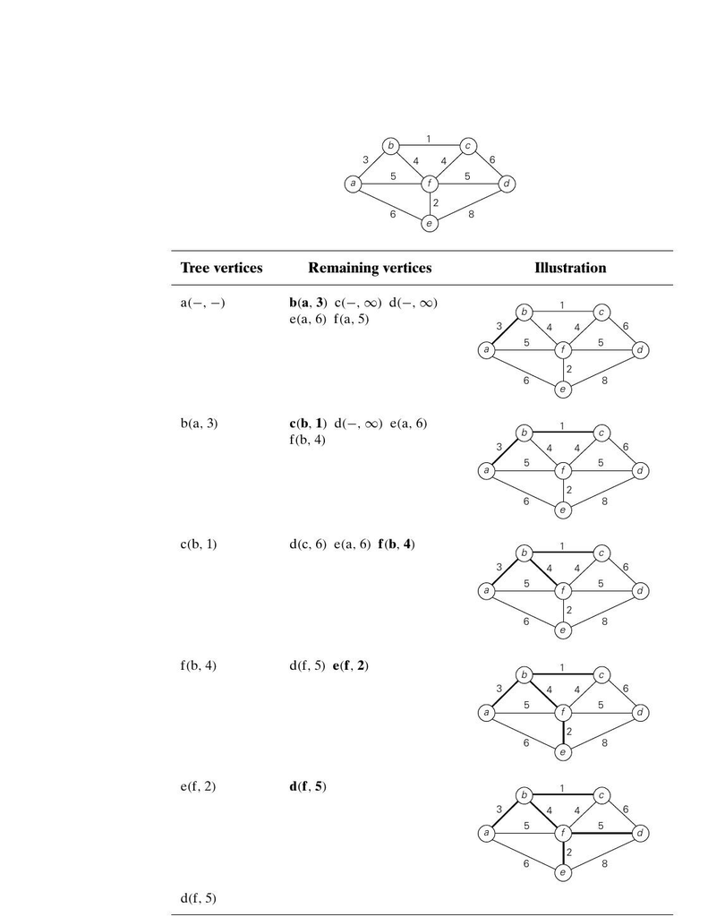

Figura 9.3: crecimiento del árbol de Prim.

04 · Árbol mínimo

## Kruskal: unir componentes

Ordena todas las aristas por peso y acepta la siguiente más barata si conecta componentes diferentes.

### Simulador de Kruskal

**0**peso MST

**0**aceptadas

**0**rechazadas

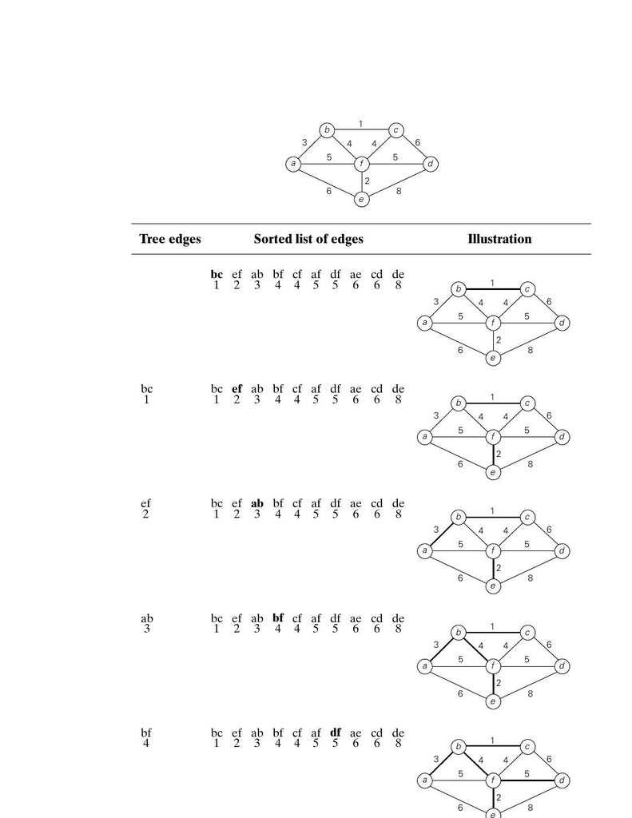

Figura 9.5: aristas ordenadas y selección sin ciclos.

05 · Caminos mínimos

## Dijkstra: fijar el más cercano

Selecciona el vértice no visitado con menor distancia tentativa y relaja las aristas que salen de él.

### Simulador

Origen

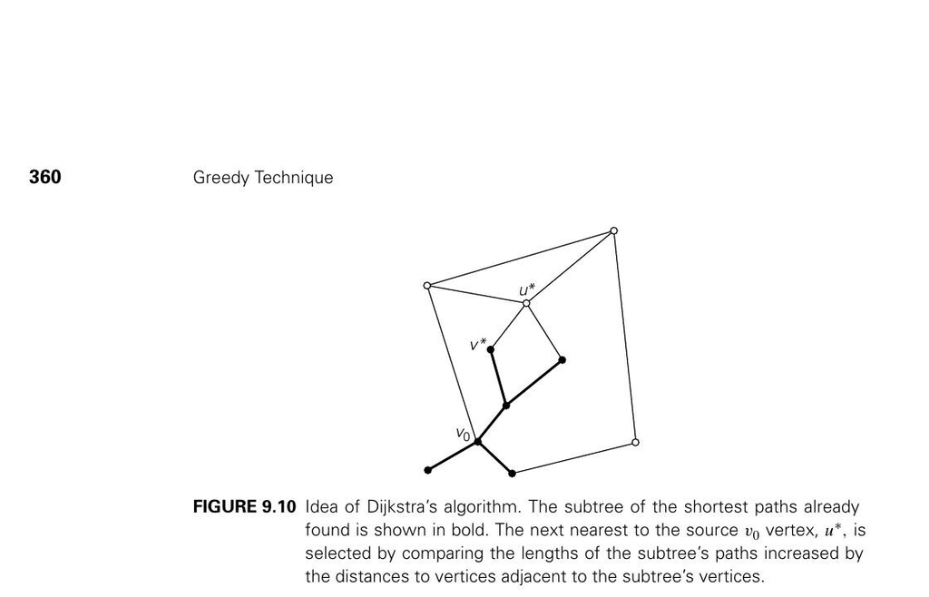

Figura 9.10: el subárbol confirmado crece hacia el siguiente vértice.

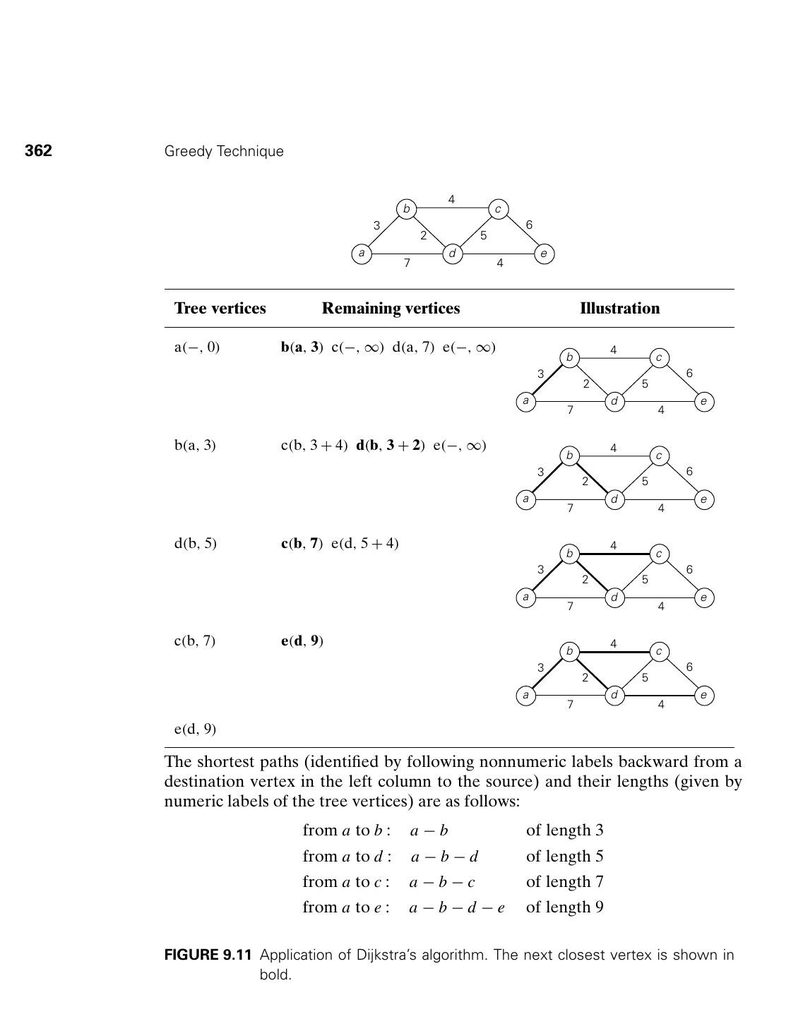

Figura 9.11: etiquetas y árbol de caminos mínimos.

06 · Compresión

## Huffman: fusionar los menos frecuentes

Combina repetidamente los dos pesos mínimos. Los símbolos frecuentes terminan con códigos cortos y ningún código es prefijo de otro.

### Constructor de código

SímbolosFrecuencias

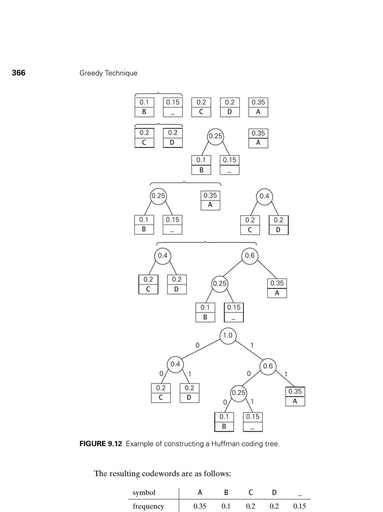

Figura 9.12: construcción voraz del árbol de codificación.

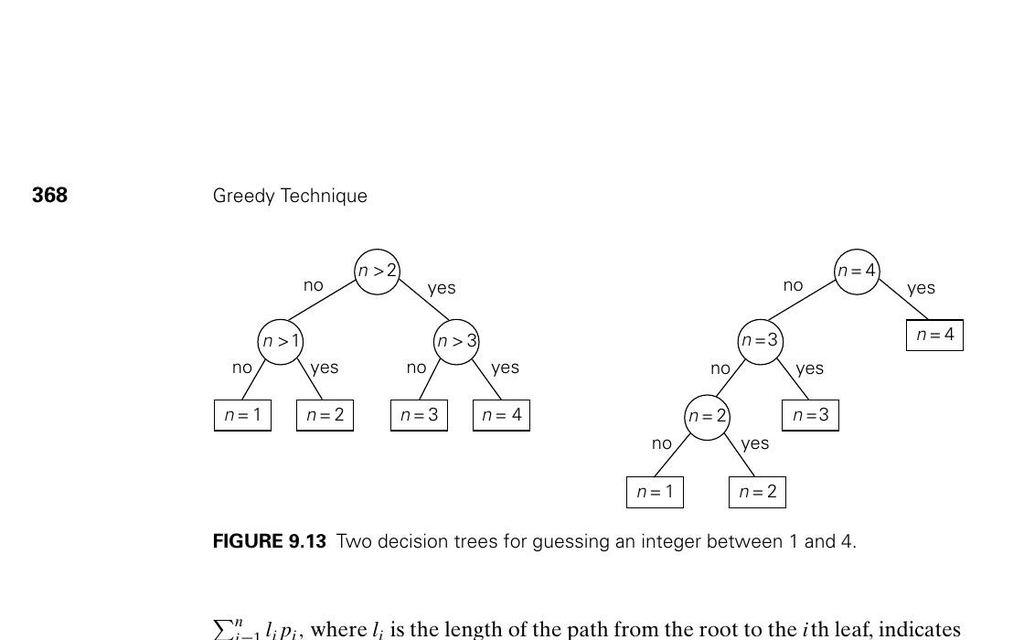

Figura 9.13: la forma del árbol altera la longitud esperada.

07 · Comparación

## La decisión que distingue a cada algoritmo

Todos son voraces, pero no comparten el mismo criterio local ni la misma estructura parcial.

Prim

### Arista de corte mínima

Crece un solo árbol. Elige la conexión más barata desde dentro hacia fuera.

O(n²) o O(m log n)

Kruskal

### Arista global mínima

Crece un bosque. Union-Find evita que la siguiente arista produzca un ciclo.

O(m log m)

Dijkstra

### Distancia tentativa mínima

Fija el vértice más cercano. Requiere pesos no negativos.

O(n²) o O(m log n)

Huffman

### Dos frecuencias mínimas

Fusiona los símbolos menos probables para minimizar la longitud media.

O(n log n)

Prueba

### Intercambio o corte

Demuestra que la elección voraz puede extenderse a una solución óptima.

Alerta

### Una buena intuición puede fallar

Cambio no canónico, mochila 0/1 y caminos con pesos negativos exigen otra estrategia.

08 · Autoevaluación

## Reto voraz

Contenido elaborado a partir de Anany Levitin, *Introduction to the Design & Analysis of Algorithms*, capítulo 9, “Greedy Technique”. Las figuras proceden del PDF proporcionado y se incluyen con finalidad educativa.